# 2_Dimensionality Reduction slides

## In this notebook:

### Explore variation in samples with principal components analysis (PCA)

#### Perform PCA on subsets of features

#### Remove outliers manually

#### Specify new subsets of data

### The following functions are introduced:

- `study.interactive_pca` and `study.plot_pca`  
  These funcitons perform [Principal Components Ananlysis](http://scikit-learn.org/stable/modules/decomposition.html) on user-selected subsets of samples and features. Samples are colored according to a dictionary saved in the Create A New Study notebook.
- `study.drop_outliers`  
  After setting the `outlier` attribute in `study.metadata.data` the samples labelled outliers are removed from `study.expression.data` and `study.splicing.data`
- `study.plot_gene` and `study.plot_event`  
  These plot the distribution of gene expression or $\psi$ in each phenotype.
- `study.merge_boolean_metadata_columns` takes mulitiple boolean (True/False) columns and returns the logical OR of these columns.

```python
import flotilla
```

```python
study = flotilla.embark("neural_diff_demo")
```

[output not shown]

```
Removing technical outliers from consideration in expression:
	M_M2nd_23
	M_M2nd_30
	M_M2nd_31
	M_M2nd_32
	M_M3_10
	P_P4_2
	P_P8_12
	P_P8_3
	P_P8_4
	P_P8_7
	P_P8_8
	P_P8_9
	S_MSA_25
Removing technical outliers from consideration in splicing:
	M_M2nd_23
	M_M2nd_30
	M_M2nd_31
	M_M2nd_32
	M_M3_10
	P_P4_2
	P_P8_12
	P_P8_3
	P_P8_4
	P_P8_7
	P_P8_8
	P_P8_9
	S_MSA_25
```

```
2014-10-31 00:46:41	Loading splicing data
2014-10-31 00:46:41	Initializing splicing
2014-10-31 00:46:41	Done initializing splicing
2014-10-31 00:46:41	Successfully initialized a Study object!
```

```
<flotilla.visualize.decomposition.DecompositionViz at 0x1151b1350>
```

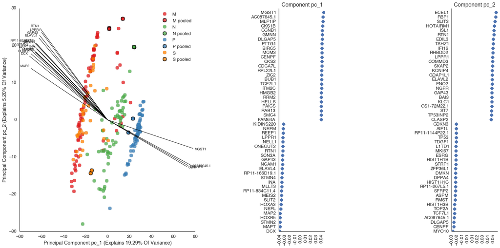

[figure not shown]

```python
study.plot_pca()
```

## Check for markers of specified lineages

### Use official gene symbols or Ensembl IDs to plot distribution of expression for a single gene.

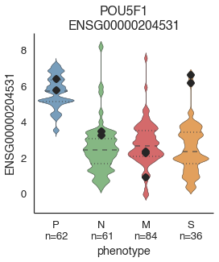

```python
study.plot_gene("POU5F1")
```

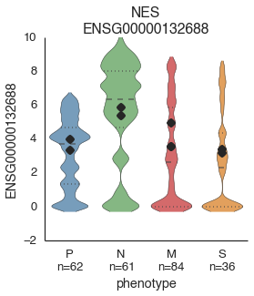

```python
study.plot_gene("NES")
```

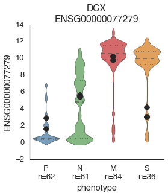

```python
study.plot_gene("DCX")
```

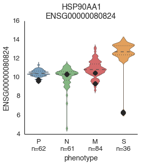

```python
study.plot_gene("HSP90AA1")
```

## Interactive PCA

### Choose feature type, sample subset, and feature subsets to perform PCA.

### By default, the most variant features among the samples selected are used to perform PCA.

### HTML widgets allow user interaction:

[figure not shown]

Alternatively (*for presentations like this for example*) users can set the range of options at the function call.

#### `interactive_pca` options:

- Select `data_type` (expression/splicing), `sample_subset`, `feature_subset` from pull-down menus.
- Transpose with *featurewise* to examine relationships between features
- Use custom lists from the internet *(Dropbox?)* or local file paths with `list_link` and the *custom* feature subset.
- Choose other principal components to plot with sliders.
- Plot violin plots with `plot_violins`
- Label samples

#### sample_subsets include:

- All boolean columns in `study.metadata.data`
- Phenotypes
- Pooled samples
- Outliers

#### `feature_subset`s include:

- Everything annotated in Gencode
  - Protein coding genes
  - lncRNA
  - snoRNA/snRNA/tRNA...
  - Pseudogenes
- And some things that are not
  - RNA-binding proteins
  - Neural celltype lineage markers from (Fluidigm) biomark panel.
  - Transcription factors

```
savefile : data/last.pca.pdf
y_pc : 2
data_type : expression
featurewise : False
show_point_labels : True
sample_subset : all_samples
feature_subset : variant
plot_violins : False
x_pc : 1
list_link :
```

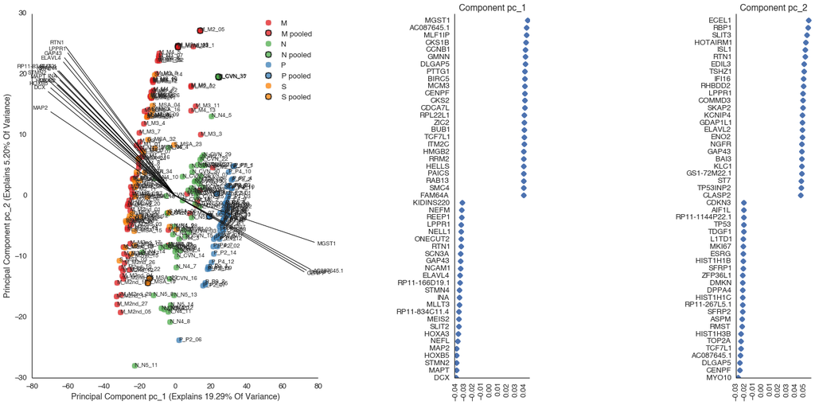

```python
study.interactive_pca(show_point_labels=True);
```

### Sample P_P2_06 and N_N5_11 look like outliers. Let's remove them.

```python
study.metadata.data.ix[['P_P2_06', 'N_N5_11'], 'outlier'] = True
```

```python
study.drop_outliers()
```

```
dropping expression outliers
dropping set(['P_P2_06', 'N_N5_11'])
dropping splicing outliers
dropping set(['P_P2_06', 'N_N5_11'])
```

```
savefile : data/last.pca.pdf
y_pc : 2
data_type : expression
featurewise : False
show_point_labels : False
sample_subset : all_samples
feature_subset : variant
plot_violins : False
x_pc : 1
list_link :
```

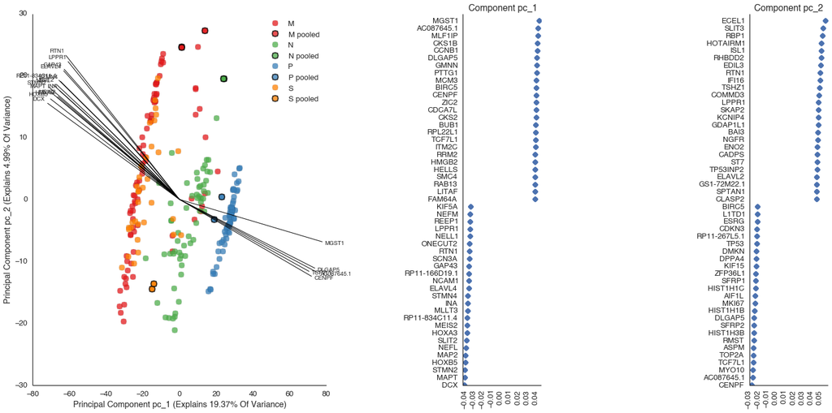

```python
study.interactive_pca();
```

### Use `'~'` to indicate the logical inverse of a column

```
savefile : data/last.pca.pdf
y_pc : 2
data_type : expression
featurewise : False
show_point_labels : False
sample_subset : ~P_cell
feature_subset : gene_type: protein_coding
plot_violins : False
x_pc : 1
list_link :
```

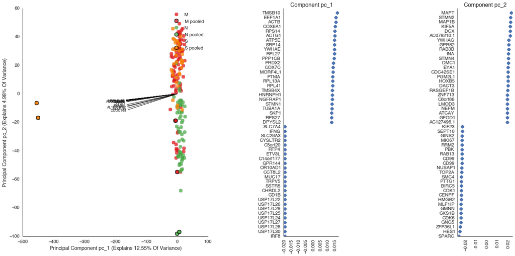

```python
study.interactive_pca(sample_subsets=["~P_cell"],
                      feature_subsets=['gene_type: protein_coding']);
```

### Make new subsets to plot

#### Get cells that are either P, S or pooled (i.e. only N and M single cells `== False`).

```python
study.metadata.data['PS_pooled_cells'] = study.merge_boolean_metadata_columns(['P_cell',
                                                                              'S_cell',
                                                                              'pooled_samples'])
```

```
savefile : data/last.pca.pdf
y_pc : 2
data_type : expression
featurewise : False
show_point_labels : False
sample_subset : ~PS_pooled_cells
feature_subset : gene_type: protein_coding
plot_violins : False
x_pc : 1
list_link :
```

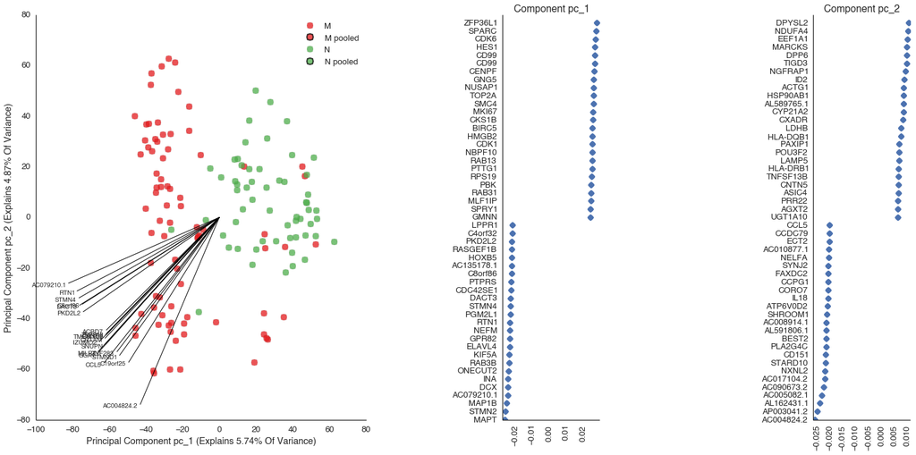

```python
study.interactive_pca(sample_subsets=["~PS_pooled_cells"],
                      feature_subsets=['gene_type: protein_coding']);
```

### Check a gene list from a collaborator.

```
savefile : data/last.pca.pdf
y_pc : 2
data_type : expression
featurewise : False
show_point_labels : False
sample_subset : ~PS_pooled_cells
feature_subset : custom
plot_violins : False
x_pc : 1
list_link : https://www.dropbox.com/s/qddybszcses6pi6/DE_genes.male%20adult%20%2019.txt?dl=0
link https://www.dropbox.com/s/qddybszcses6pi6/DE_genes.male%20adult%20%2019.txt?dl=0
```

```
WARNING, downloading things from the internet, potential danger from untrusted sources
```

```
<function flotilla.visualize.ipython_interact.do_interact>
```

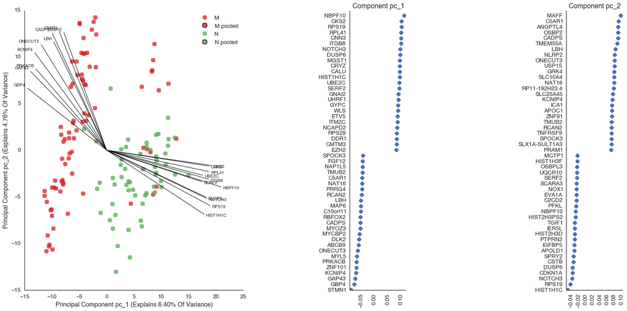

```python
study.interactive_pca(sample_subsets=["~PS_pooled_cells"],
                      feature_subsets=['custom'],
                      list_link="https://www.dropbox.com/s/qddybszcses6pi6/DE_genes.male%20adult%20%2019.txt?dl=0")
```

### Keep all changes (*i.e. the new metadata column*) for the next embark.

```python
study.save("neural_diff_demo")
```

```
Wrote datapackage to /Users/lovci/flotilla_projects/neural_diff_demo/datapackage.json
```

## Summary

With minimal coding users can interact and visualize complex patterns in their data.

Users can:

- Examine expression of interesting genes among phenotypes
- Modify parameters with interactive HTML widgets
- Select the inverse of sample subsets.
- Modify sample/feature subsets on the fly.
- Use feature lists from web sources.